# R for geographic map: Session 1

Yedomon

2020-07-12

Welcome to the training module designed for postdocs and alumni fellows in the *Climap Africa*

programme. We will work today with the open data science tool **R**.

**Course objective**: Enhance R users for informative geographic maps rendering using R

**Notice**: Please visit the hyperlink (in blue) for installation and settings.

**Pre-requisites**:

- Install [R](https://cran.r-project.org/bin/windows/base/) and [RStudio](https://rstudio.com/products/rstudio/download/) on Windows 7, 8 or 10. A tutorial for a beginner is [here](https://medium.com/@GalarnykMichael/install-r-and-rstudio-on-windows-5f503f708027).
- Install the following packages before the course: rgdal, mapdata, mapproj, maps, ggplot2, ggrepel, legendMap, dplyr, scales, and ggmap. A tutorial for package installation in RStudio is [here](https://subscription.packtpub.com/book/big_data_and_business_intelligence/9781783980246/1/ch01lvl1sec11/installing-libraries-in-r-and-rstudio).
- Download the data for exercise [here](https://drive.google.com/file/d/1Ztiykmo0R5R9hJJB3qOaZwzyLC20rrt1/view)

# Course outline

1. Working directory setting, data preparation and shapefile importation (5 mn)
2. Rendering a basic map in R using ggplot2 (10 min)
3. Rendering a choropleth map (20 min)
4. Add a scale bar and North Arrow (5 min)
5. Tips (5 min)
6. Q & A (15 min)

# 1. Working directory setting, data preparation and shapefile importation

## 1.1. Set the working directory

The working directory is the folder named `R MAP`. Please put all the shapefiles and data in your working disrectory. To set your working directory, type:

```r
setwd("C:/Users/ANGE/Documents/R MAP")
```

## 1.2. Clean the R environment workspace

```r
rm(list = ls())
```

## 1.3. Set shapefile path

```r
mySHP = "C:/Users/ANGE/Documents/R MAP"
```

## 1.4. Import the shapefile

```r
myFile = readOGR(mySHP, layer = "SEN_adm1", stringsAsFactors = FALSE)
```

## 1.5. Check the class of the shapefile

```r
class(myFile)
```

```
[1] "SpatialPolygonsDataFrame"
attr(,"package")
[1] "sp"
```

## 1.6. Check the variables names

```r
names(myFile)
```

```
[1] "ID_0"      "ISO"       "NAME_0"    "ID_1"      "NAME_1"    "TYPE_1"
[7] "ENGTYPE_1" "NL_NAME_1" "VARNAME_1"
```

## 1.7. Check the regions names

```r
print(myFile$NAME_1)
```

```
 [1] "Dakar"       "Diourbel"    "Fatick"      "KÃ©dougou"   "Kaffrine"
 [6] "Kaolack"     "Kolda"       "Louga"       "Matam"       "SÃ©dhiou"
[11] "Saint-Louis" "Tambacounda" "ThiÃ¨s"      "Ziguinchor"
```

## 1.5. Library loading

```r
library(rgdal)
library(mapdata)
library(mapproj)
library(maps)
library(ggplot2)
library(ggrepel)
library(legendMap)
library(dplyr)
library(scales)
library(ggmap)
```

# 2. Rendering a basic map in R using ggplot2

## 2.1. Change in dataframe format for ggplot2

```r
myDF = fortify(myFile, region = "NAME_1")
```

## 2.2. Overview of the data myDF

Type: `head(myDF, 4`

| long | lat | order | hole | piece | id | group |
| --- | --- | --- | --- | --- | --- | --- |
| -17.16056 | 14.89375 | 1 | FALSE | 1 | Dakar | Dakar.1 |
| -17.16004 | 14.89333 | 2 | FALSE | 1 | Dakar | Dakar.1 |
| -17.16000 | 14.89335 | 3 | FALSE | 1 | Dakar | Dakar.1 |
| -17.15683 | 14.89042 | 4 | FALSE | 1 | Dakar | Dakar.1 |

## 2.3. Change long to Longitude and lat to Latitude

```r
myDF = rename(myDF, Longitude = long, Latitude = lat)
```

## 2.4.Overview of the myDF

Type: `head(myDF, 4)`

| Longitude | Latitude | order | hole | piece | id | group |
| --- | --- | --- | --- | --- | --- | --- |
| -17.16056 | 14.89375 | 1 | FALSE | 1 | Dakar | Dakar.1 |
| -17.16004 | 14.89333 | 2 | FALSE | 1 | Dakar | Dakar.1 |
| -17.16000 | 14.89335 | 3 | FALSE | 1 | Dakar | Dakar.1 |
| -17.15683 | 14.89042 | 4 | FALSE | 1 | Dakar | Dakar.1 |

## 2.5. Make the basic plot

```r
p <- ggplot() + geom_polygon(data = myDF, aes(x = Longitude, y = Latitude, group = group),
    color = "black", size = 0.25) + coord_map() + theme_minimal() + ggtitle("Basic map with ggplot2")
```

The map is in p

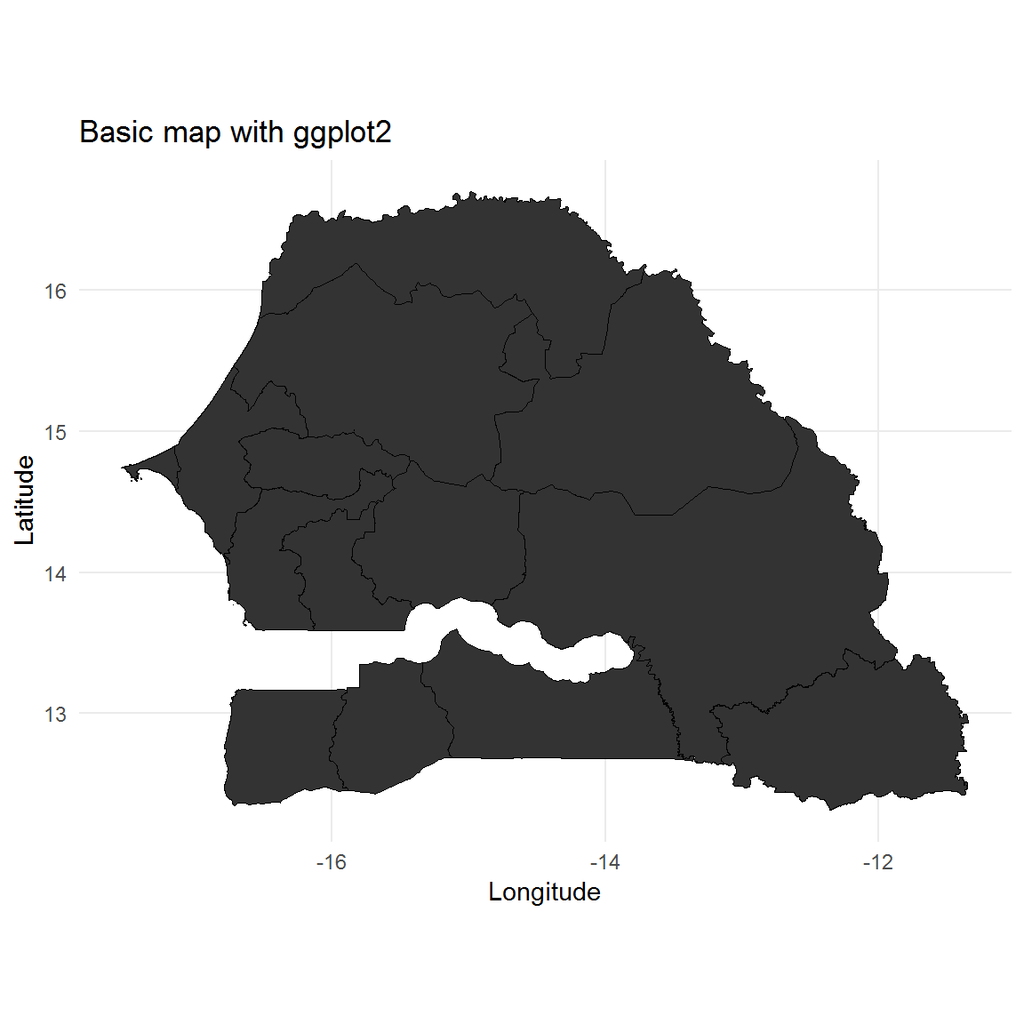

# 3. Rendering a choropleth map

## 3.1. Import the data we want to plot on the map.Here that is the production of pearl millet per region

```r
mydata = read.csv("production_data.csv", header = TRUE, sep = ";")
```

## 3.2. Import the the regions names for annotation step

```r
mydata1 = read.csv("region_names.csv", header = TRUE, sep = ";")
```

## 3.3. Overview of the data mydata

Type:`head(mydata, 4)`

| long | lat | id | Production |
| --- | --- | --- | --- |
| -17.33 | 14.75 | Dakar | 0 |
| -16.25 | 14.75 | Diourbel | 46231 |
| -16.53 | 14.36 | Fatick | 80000 |
| -12.18 | 12.80 | KÃ©dougou | 152 |

## 3.4Overview of the data mydata1

Type: `head(mydata1, 4)`

| Region | long | lat |
| --- | --- | --- |
| DAKAR | -17.33 | 14.75 |
| DIOURBEL | -16.25 | 14.75 |
| FATICK | -16.53 | 14.36 |
| KAOLACK | -16.00 | 14.00 |

## 3.4. Join the data and the shapefle

```r
plotData <- left_join(myDF, mydata)
```

**Key point: Note that myDF and mydata has id as a common variable**

## 3.5. Overview of plotData

Type: `head(plotData`

| Longitude | Latitude | order | hole | piece | id | group | long | lat | Production |
| --- | --- | --- | --- | --- | --- | --- | --- | --- | --- |
| -17.16056 | 14.89375 | 1 | FALSE | 1 | Dakar | Dakar.1 | -17.33 | 14.75 | 0 |
| -17.16004 | 14.89333 | 2 | FALSE | 1 | Dakar | Dakar.1 | -17.33 | 14.75 | 0 |
| -17.16000 | 14.89335 | 3 | FALSE | 1 | Dakar | Dakar.1 | -17.33 | 14.75 | 0 |
| -17.15683 | 14.89042 | 4 | FALSE | 1 | Dakar | Dakar.1 | -17.33 | 14.75 | 0 |

## 3.6 Make the plot

```r
p <- ggplot() +

geom_polygon(data = plotData, aes(x = Longitude, y = Latitude, group = group,
    fill = Production), color = "black", size = 0.25) +

coord_map() +


scale_fill_distiller(palette = "Greens", direction = 1) +

geom_point(data = mydata1, aes(x = long, y = lat), shape = 21, fill = "white",
    size = 3, color = "black") +

geom_label_repel(data = mydata1, aes(x = long, y = lat, label = Region), fontface = "bold",
    color = "black", box.padding = 0.35, point.padding = 0.5, segment.color = "grey10") +


theme_minimal() +

theme(panel.grid.major = element_line(colour = "black", size = 0.5, linetype = "dotted")) +
    theme(plot.background = element_rect(colour = "white", size = 1)) +

ggtitle("Map of Pearl Millet Production in Senegal (Rainy season 2017)")
```

### Map rendering

Just call the map variable p

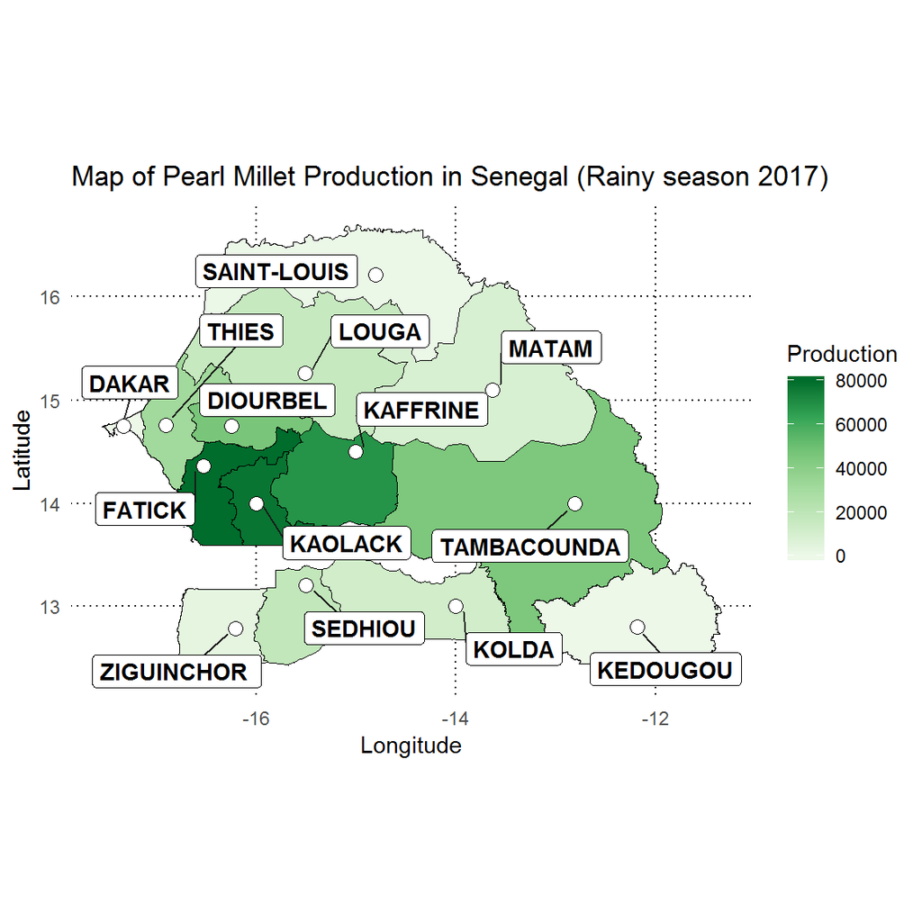

That is it!

# 4. Add scale bar and north arrow

```r
p <- ggplot() +


geom_polygon(data = plotData, aes(x = Longitude, y = Latitude, group = group,
    fill = Production), color = "black", size = 0.25) +

coord_map() +

scale_fill_distiller(palette = "Greens", direction = 1) +
geom_point(data = mydata1, aes(x = long, y = lat), shape = 21, fill = "white",
    size = 3, color = "black") +

geom_label_repel(data = mydata1, aes(x = long, y = lat, label = Region), fontface = "bold",
    color = "black", box.padding = 0.35, point.padding = 0.5, segment.color = "grey10") +

scale_bar(lon = -12, lat = 16, distance_lon = 40, distance_lat = 10, distance_legend = 25,
    dist_unit = "km", arrow_length = 10, arrow_distance = 50, arrow_north_size = 6) +

theme_minimal() +

theme(panel.grid.major = element_line(colour = "black", size = 0.5, linetype = "dotted")) +
    theme(plot.background = element_rect(colour = "white", size = 1)) +
ggtitle("Map of Pearl Millet Production in Senegal (Rainy season 2017)")
```

### Map rendering

Just call the map variable p

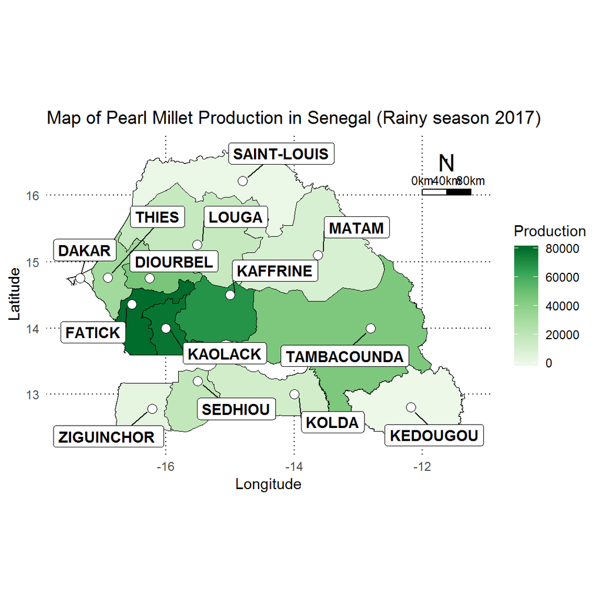

**Export a high quality map** by typing:

**PDF format**

```
ggsave(p, file = "carte.pdf", limitsize = FALSE, width = 12, height = 10.5, dpi=500 )
```

**PNG format**

```
ggsave(p, file = "carte.png", limitsize = FALSE, width = 10, height = 6.5, type = "cairo-png", dpi=500)
```

# 5. Tips

To find out a desirable position for scale bar or any adjustment, it is possible to plot the map with the basic R by typing:

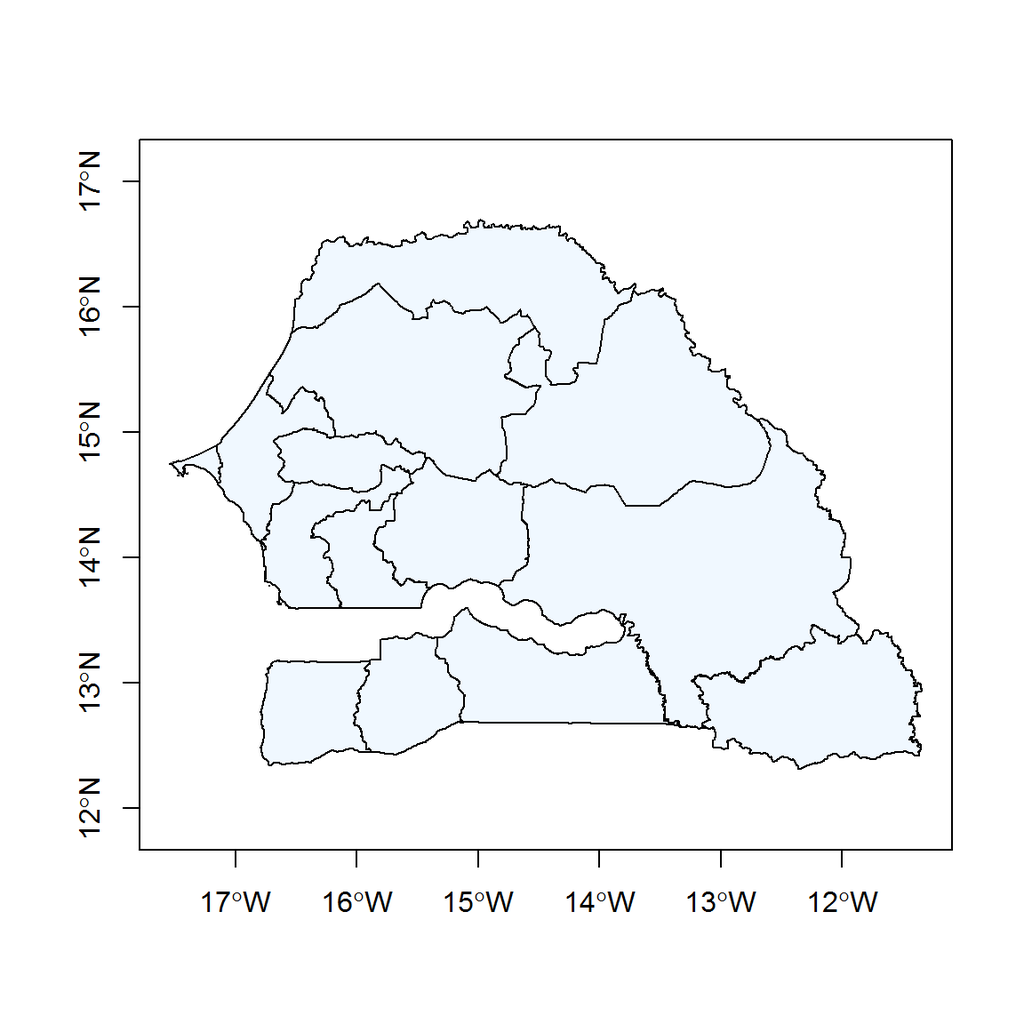

```r
plot(myFile, axes = T, col = "aliceblue")
```

and then typing:

```
locator(n=2)  # 2 is just an example. You can define many number as much as possible
```

and using your mouse, click on the position you want. You will get the coordinates.

# 6. Q & A